# STAT 540 Seminar 03: R graphics - 'lattice' version

## STAT 540 Seminar 03: R graphics - 'lattice' version

### Hao Chen

**2014-02-10**

- Load the photoRec dataset and required packages
- The “you try” questions
- Take-home problem

> The R markdown file can be found on my [Github](https://github.com/nelsonch/stat540-2014-chen-hao/blob/master/seminar%2003/seminar03_graphics-lattice.Rmd).

### Load the photoRec dataset and required packages

The following datasets will be covered in this seminar:

- GSE4051_MINI.rds: mini gene expression dataset
- GSE4051_data.tsv: full data matrix
- GSE4051_design.rds: experimental design

Load required datasets:

```r
> kDat <- readRDS("GSE4051_MINI.rds")
> str(kDat)
```

```
'data.frame':   39 obs. of  7 variables:
 $ sidChar   : chr  "Sample_20" "Sample_21" "Sample_22" "Sample_23" ...
 $ sidNum    : num  20 21 22 23 16 17 6 24 25 26 ...
 $ devStage  : Factor w/ 5 levels "E16","P2","P6",..: 1 1 1 1 1 1 1 2 2 2 ...
 $ gType     : Factor w/ 2 levels "wt","NrlKO": 1 1 1 1 2 2 2 1 1 1 ...
 $ crabHammer: num  10.22 10.02 9.64 9.65 8.58 ...
 $ eggBomb   : num  7.46 6.89 6.72 6.53 6.47 ...
 $ poisonFang: num  7.37 7.18 7.35 7.04 7.49 ...
```

```r
> prDat <- read.table("GSE4051_data.tsv")
> str(prDat, max.level = 0)
```

```
'data.frame':   29949 obs. of  39 variables:
```

```r
> prDes <- readRDS("GSE4051_design.rds")
> str(prDes)
```

```
'data.frame':   39 obs. of  4 variables:
 $ sidChar : chr  "Sample_20" "Sample_21" "Sample_22" "Sample_23" ...
 $ sidNum  : num  20 21 22 23 16 17 6 24 25 26 ...
 $ devStage: Factor w/ 5 levels "E16","P2","P6",..: 1 1 1 1 1 1 1 2 2 2 ...
 $ gType   : Factor w/ 2 levels "wt","NrlKO": 1 1 1 1 2 2 2 1 1 1 ...
```

Load required R packages:

```r
> library(lattice)   # for plotting
> library(gridExtra)   # for grid graphics
> library(RColorBrewer)  # for color palettes
> library(gplots)  # for heatmap
```

```
Copyright M. P. Wand 1997-2009
```

### The “you try” questions

[You try 1](http://ugrad.stat.ubc.ca/%7Estat540/seminars/seminar03_graphics-lattice.html#scatterplots): request a scatterplot of the variable poisonFang against crabHammer.

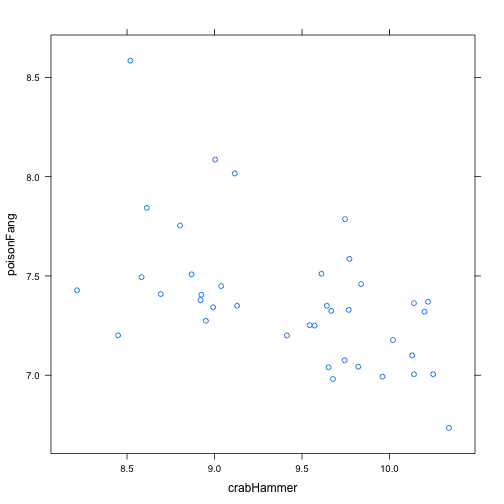

```r
> xyplot(poisonFang ~ crabHammer, kDat)
```

[You try 2](http://ugrad.stat.ubc.ca/%7Estat540/seminars/seminar03_graphics-lattice.html#stripplot): Remake this plot but instead of conveying genotype via color, show developmental stage.

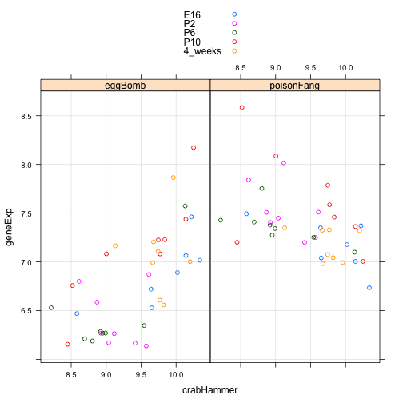

```r
> nDat <- with(kDat, data.frame(sidChar, sidNum, devStage, gType, crabHammer,
+                               probeset = factor(rep(c("eggBomb", "poisonFang"),
+                                                     each = nrow(kDat))),
+                               geneExp = c(eggBomb, poisonFang)))
>
> xyplot(geneExp ~ crabHammer | probeset, nDat, grid = TRUE, groups = devStage, auto.key = TRUE)
```

[You try 3](http://ugrad.stat.ubc.ca/%7Estat540/seminars/seminar03_graphics-lattice.html#stripplot): Use `densityplot()` to explore the gene expression distribution by gene and/or developmental stage. Play with 'bw' and 'n' if you like.

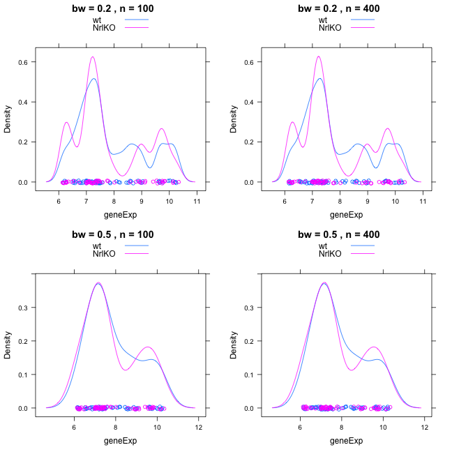

```r
> oDat <- with(kDat, data.frame(sidChar, sidNum, devStage, gType,
+                               probeset = factor(rep(c("crabHammer", "eggBomb", "poisonFang"),
+                                                     each = nrow(kDat))),
+                               geneExp = c(crabHammer, eggBomb, poisonFang)))
>
> denplotfun <- function(jBw, jn){
+   densityplot(~ geneExp, oDat, groups = gType, auto.key = TRUE,
+               bw = jBw, n = jn, main = paste("bw =", jBw, ", n =", jn))
+ }
>
> fig1 <- denplotfun(0.2, 100)
> fig2 <- denplotfun(0.2, 400)
> fig3 <- denplotfun(0.5, 100)
> fig4 <- denplotfun(0.5, 400)
>
> grid.arrange(fig1, fig2, fig3, fig4, nrow=2)
```

### Take-home problem

[Take-home problem](http://ugrad.stat.ubc.ca/%7Estat540/seminars/seminar03_graphics-lattice.html#take-home-problem): The full photoRec dataset has 39 samples and 29949 probesets. Choose 2 … or 20 … or 200 random probesets/genes and look for gene expression differences between the two genotypes, wild type versus knockout. Make use of the graphing techniques discussed this week such as scatter plots, data heatmaps, correlation heatmaps, etc.

Draw 30 probesets at random.

```r
> set.seed(540)
> yo <- sample(1:nrow(prDat), size = 30)
> hDat <- prDat[yo, ]
> hDat <- as.matrix(t(hDat))
> rownames(hDat) <- with(prDes, paste(devStage, gType, sidChar, sep="_"))
> str(hDat)
```

```
 num [1:39, 1:30] 7.38 7.21 7.3 7 6.95 ...
 - attr(*, "dimnames")=List of 2
  ..$ : chr [1:39] "E16_wt_Sample_20" "E16_wt_Sample_21" "E16_wt_Sample_22" "E16_wt_Sample_23" ...
  ..$ : chr [1:30] "1417558_at" "1453147_at" "1450169_at" "1430577_at" ...
```

### Scatter plot

Randomly draw 4 samples from 39 samples intotal

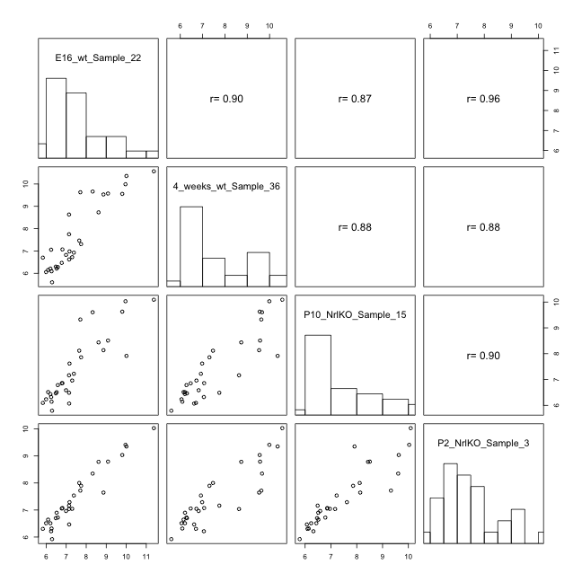

```r
> set.seed(540)
> yo <- sample(1:nrow(hDat), size = 4)
> pairDat <- t(hDat[yo, ])
>
> panel.cor <- function(x, y, digits=2, cex.cor)
+ {
+   usr <- par("usr"); on.exit(par(usr))
+   par(usr = c(0, 1, 0, 1))
+   r <- abs(cor(x, y))
+   txt <- format(c(r, 0.123456789), digits=digits)[1]
+   text(0.5, 0.5, paste("r=",txt), cex=1.5)
+ }
>
> panel.hist <- function(x, ...)
+ {
+   usr <- par("usr"); on.exit(par(usr))
+   par(usr = c(usr[1:2], 0, 1.5) )
+   h <- hist(x, plot = FALSE)
+   breaks <- h$breaks; nB <- length(breaks)
+   y <- h$counts; y <- y/max(y)
+   rect(breaks[-nB], 0, breaks[-1], y, ...)
+ }
>
> pairs(pairDat, upper.panel=panel.cor, diag.panel=panel.hist)
```

### Data heatmap

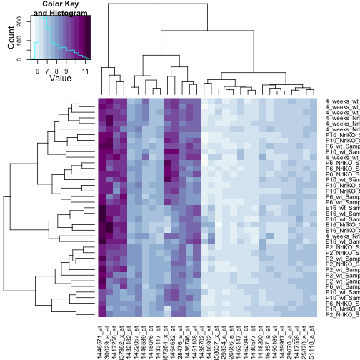

```r
> jBuPuFun <- colorRampPalette(brewer.pal(n = 9, "BuPu"))
> heatmap.2(hDat, col = jBuPuFun, trace = "none")
```

### Correlation heatmap

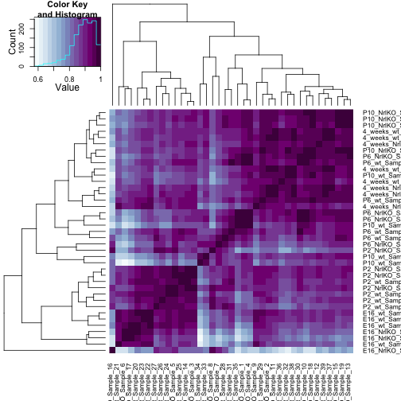

```r
> heatmap.2(cor(t(hDat)), col = jBuPuFun, trace = "none")
```